# Practical Machine Learning

Joel

May 24, 2018

# Data

The training data for this project are available here:

https://d396qusza40orc.cloudfront.net/predmachlearn/pml-training.csv

The test data are available here:

https://d396qusza40orc.cloudfront.net/predmachlearn/pml-testing.csv

The data for this project come from this source: http://web.archive.org/web/20161224072740/http:/groupware.les.inf.puc-rio.br/har.

# Background

Using devices such as Jawbone Up, Nike FuelBand, and Fitbit it is now possible to collect a large amount of data about personal activity relatively inexpensively. These type of devices are part of the quantified self movement – a group of enthusiasts who take measurements about themselves regularly to improve their health, to find patterns in their behavior, or because they are tech geeks. One thing that people regularly do is quantify how much of a particular activity they do, but they rarely quantify how well they do it.

In this project, your goal will be to use data from accelerometers on the belt, forearm, arm, and dumbell of 6 participants. They were asked to perform barbell lifts correctly and incorrectly in 5 different ways.

Six young health participants were asked to perform one set of 10 repetitions of the Unilateral Dumbbell Biceps Curl in five different fashions:

exactly according to the specification (Class A) throwing the elbows to the front (Class B) lifting the dumbbell only halfway (Class C) lowering the dumbbell only halfway (Class D) throwing the hips to the front (Class E).

# Loading necessary packages

```r
# to model the data
library(caret)
```

```r
# To visualize
library(corrplot)
# parallel processing
library(doParallel)
```

# Downloading the data

```r
training <- read.csv(url("http://d396qusza40orc.cloudfront.net/predmachlearn/pml-training.csv"), na.strings=c("NA","#DIV/0!",""))

testing <- read.csv(url("http://d396qusza40orc.cloudfront.net/predmachlearn/pml-testing.csv"), na.strings=c("NA","#DIV/0!",""))
```

Dimension of the data frame

```r
dim(training)
```

```
## [1] 19622   160
```

```r
dim(testing)
```

```
## [1]  20 160
```

Training data set has 160 variables and 19622 observations. Testing data set has 160 variables and 20 observations

```r
head(training)
```

[output not shown]

[output cut: 265 more lines]

We observe that a lot of columns have NAs.

```r
head(training[,9:20])
```

```
##   pitch_belt yaw_belt total_accel_belt kurtosis_roll_belt
## 1       8.07    -94.4                3                 NA
## 2       8.07    -94.4                3                 NA
## 3       8.07    -94.4                3                 NA
## 4       8.05    -94.4                3                 NA
## 5       8.07    -94.4                3                 NA
## 6       8.06    -94.4                3                 NA
##   kurtosis_picth_belt kurtosis_yaw_belt skewness_roll_belt
## 1                  NA                NA                 NA
## 2                  NA                NA                 NA
## 3                  NA                NA                 NA
## 4                  NA                NA                 NA
## 5                  NA                NA                 NA
## 6                  NA                NA                 NA
##   skewness_roll_belt.1 skewness_yaw_belt max_roll_belt max_picth_belt
## 1                   NA                NA            NA             NA
## 2                   NA                NA            NA             NA
## 3                   NA                NA            NA             NA
## 4                   NA                NA            NA             NA
## 5                   NA                NA            NA             NA
## 6                   NA                NA            NA             NA
##   max_yaw_belt
## 1           NA
## 2           NA
## 3           NA
## 4           NA
## 5           NA
## 6           NA
```

We will remove the NAs as we find columns with more than 90% NA

```r
sum(sapply(training, function(x)sum(is.na(x))/length(x))>0.9)
```

```
## [1] 100
```

excluding 100 variables out of 160

```r
training <- training[,!sapply(training, function(x) sum(is.na(x))/length(x))>0.9]
```

Repeating same on the test data

```r
testing <- testing[,!sapply(testing, function(x) sum(is.na(x))/length(x))>0.9]
```

removing unnecessary variables

```r
training <- training[,-(1:7)]
testing  <- testing [,-(1:7)]
```

Looking at the correlation of the variables

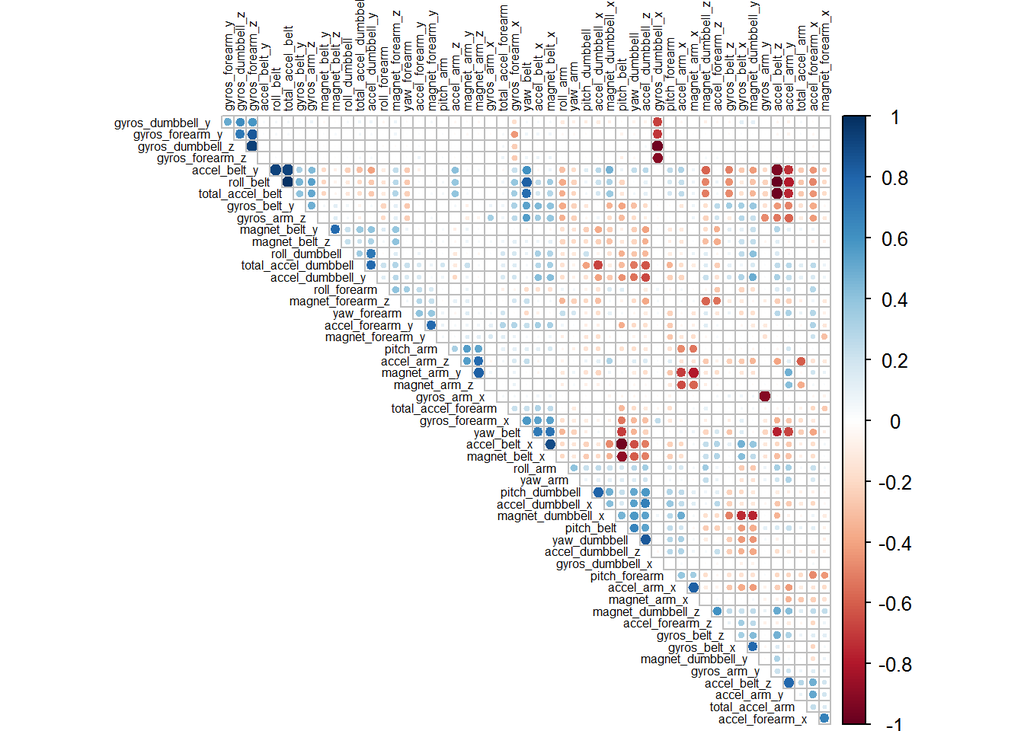

```r
corrVar <- cor(training[,1:52])
corrplot(corrVar,  type = "upper", tl.pos = "td",method = "circle", tl.cex = 0.5, tl.col = 'black',order = "hclust", diag = FALSE)
```

Finding columns with more than .75 correlation

```r
CorrCol <- findCorrelation(corrVar, cutoff=0.75)
length(CorrCol)
```

```
## [1] 21
```

21 is the number of columns to be removed

Now, to remove correlated variables

```r
training <- training[,-CorrCol]
testing  <- testing[,-CorrCol]
```

Plotting it

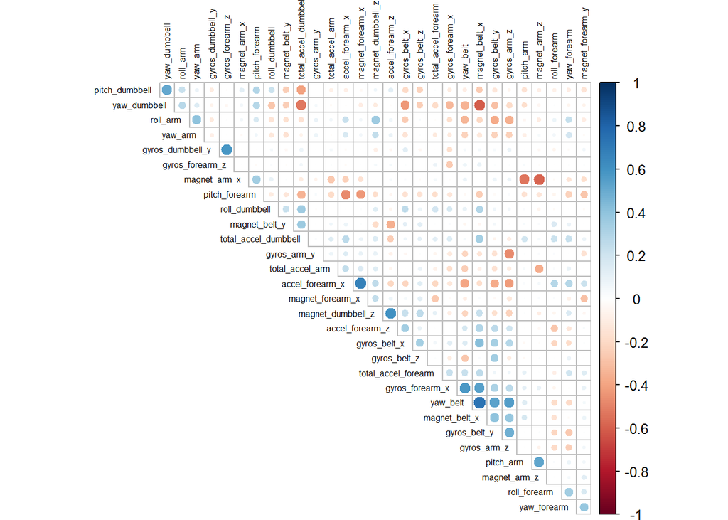

```r
corrplot(cor(training[,1:30]),  type = "upper", tl.pos = "td",method = "circle", tl.cex = 0.5, tl.col = 'black',order = "hclust", diag = FALSE)
```

# Modeling the dataset

Ensuring the result can be replayed

```r
registerDoParallel()
set.seed(120)
```

Using k-fold cross validation

```r
TC <- trainControl(method = "cv", number = 10)
```

Using Random Forest Method

```r
RF <- train(classe~., data=training, trControl=TC, method="rf")
RF
```

```
## Random Forest
##
## 19622 samples
##    31 predictor
##     5 classes: 'A', 'B', 'C', 'D', 'E'
##
## No pre-processing
## Resampling: Cross-Validated (10 fold)
## Summary of sample sizes: 17662, 17661, 17659, 17659, 17660, 17660, ...
## Resampling results across tuning parameters:
##
##   mtry  Accuracy   Kappa
##    2    0.9941902  0.9926508
##   16    0.9937316  0.9920708
##   31    0.9838446  0.9795637
##
## Accuracy was used to select the optimal model using the largest value.
## The final value used for the model was mtry = 2.
```

Using decision tree method to model data

```r
FitRP <- train(classe~., data=training, trControl=TC, method = "rpart")
FitRP
```

```
## CART
##
## 19622 samples
##    31 predictor
##     5 classes: 'A', 'B', 'C', 'D', 'E'
##
## No pre-processing
## Resampling: Cross-Validated (10 fold)
## Summary of sample sizes: 17660, 17660, 17661, 17660, 17661, 17659, ...
## Resampling results across tuning parameters:
##
##   cp          Accuracy   Kappa
##   0.02741775  0.5314982  0.4108174
##   0.02934055  0.5107060  0.3855615
##   0.04226606  0.3896948  0.1834884
##
## Accuracy was used to select the optimal model using the largest value.
## The final value used for the model was cp = 0.02741775.
```

As you can see above, the Random Forest prediction has a much higher accuracy than the Decision Tree accuracy. Therefore we will use the Random Forest prediction to predict our test cases.

The prediction of our algorithm for the test set is:

```r
predictingrf <- predict(RF,testing)
predictingrf
```

```
##  [1] B A B A A E D B A A B C B A E E A B B B
## Levels: A B C D E
```

We then save the output to files according to instructions and post it to the submission page.

```r
FileWrite = function(x){
    n = length(x)
    path <- "./PA"
    for(i in 1:n){
        filename = paste0("problem_id_",i,".txt")
        write.table(x[i],file=file.path(path, filename),quote=FALSE,row.names=FALSE,col.names=FALSE)
    }
}

FileWrite(predictingrf)
```